# L07 - Wrangling and Data Verbs

Data Computing Chapter 7

Presenter- Olivia Beck  
Content Credit- Dr. Matthew Beckman

May 29, 2023

# Agenda

- Introduce some software and commands that …
  - make it easy to access data tables and see how they are structured
    - For example: `data()`, `View()`, `help()`,
    - (more coming in Chapter 10)
  - learn about data verbs
  - implement two important data verbs: `group_by()` and `summarise()`

# Three Important Concepts

1. Data can be usefully organized into tables with “cases” and “variables.”
   - In “tidy data” every case is the same sort of thing (e.g. a person, a car, a year, a country in a year)
   - We sometimes even modify data in order to change what the cases represent in order to better represent a point.
2. Data graphics and “glyph-ready” data
   - each case corresponds to a “glyph” (mark) on the graph
   - each variable to a graphical attribute of that glyph such as x- or y-position, color, size, length, shape, etc.
   - same is true for more technical tools (e.g., models, predictions, etc.)
3. When data are not yet in glyph-ready form, you can transform (i.e. wrangle) them into glyph-ready form.
   - Such transformations are accomplished by performing one or more of a small set of basic operations on data tables
   - This is the work of data “verbs”

# Learning about the raw data

There are lots of ways to load data into your environment

- Most real data sources will require you to
  - read a file (e.g., CSV)
  - query a database (e.g., SQL)
  - configure an API
  - scrape from the web
- For convenience, many STAT 184 data sets are accessed from R packages or CSV files
- When acquiring data, it’s very important to pause and think about data provenance/origins
  - What might be useful to learn?
  - How is this accomplished?
  - Why does it matter?

# Recall: Key goals of a careful Exploratory Data Analysis?

1. **Examine the data source:** variable types, coding, missingness, summary statistics/plots, who/what/when/where/why/how data were collected
2. **Discover features that influence may modeling decisions:** investigate potential outliers, consideration for recoding variables (e.g., numeric data that’s functionally dichotomous), evaluate correlation structure (e.g., autocorrelation, hierarchy, spatial/temporal proximity)
3. **Address research questions:** build intuition and note preliminary observations/conclusions related to each research question. Also, note observations that prompt you to refine your research questions or add new questions to investigate

#### A few simple commands to help us “Examine the data source”:

- *Note:* often you need to examine information sources outside R to do a thorough examination.
- `help()` or `?`: if your data are part of an R package, this opens a help window with details about the data
- `data()`: if your data are part of an R package, this function loads the data set into your R environment and binds an object name
- `head(Dat)`: inspect the first few rows of `Dat`
- `View(Dat)`: opens a spreadsheet tab in RStudio showing `Dat` in it’s entirety
  - You can also click on the table name in the “Enviornment” Pane
  - Bad form to call `View()` in the Rmd, use the console for this one.
  - `head()` is best in the Rmd

# Guided practice

- `Minneapolis2013` data set in the `dcData` package
  - To do this, we need to download the package from GitHub

```r
# Install the package from GitHub
# The very first time you run this, uncomment the 3 lines below

# install.packages("devtools")
# library(devtools)
# install_github("mdbeckman/dcData")
library(dcData)
data("Minneapolis2013", package = "dcData")
```

### Discussion questions:

1. What is the setting for the data?
   - What are they about?
   - Who collected them?
   - Why were they collected?
   - etc
2. How many cases are there?
3. In your own words, what kind of thing do the cases represent?
4. How many variables are there? What are their names?
5. Pick out three of the variables and say whether
   - the variable is quantitative or categorical
   - if categorical (R calls this a “factor”), what are some levels of the variable
   - if quantitative, what are the units of measurement of the variable.

Click [here](https://en.wikipedia.org/wiki/Instant-runoff_voting) to learn about rank choice voting (also called instant run off voting).

# Why we wrangle

Consider the Minneapolis 2013 election data.

```r
Minneapolis2013 %>%
  head()
```

```
##   Precinct           First      Second      Third Ward
## 1     P-10    BETSY HODGES   undervote  undervote  W-7
## 2     P-06        BOB FINE MARK ANDREW  undervote W-10
## 3     P-09 KURTIS W. HANNA    BOB FINE MIKE GOULD W-10
## 4     P-05    BETSY HODGES DON SAMUELS  undervote W-13
## 5     P-01     DON SAMUELS   undervote  undervote  W-5
## 6     P-04       undervote   undervote  undervote  W-6
```

Here’s a bar chart that might be used to show the election results:

```r
VoteResults <-
  Minneapolis2013 %>%
  group_by( First ) %>%
  summarise( votes = n() )

head(VoteResults)
```

```
## # A tibble: 6 × 2
##   First                          votes
##   <chr>                          <int>
## 1 "ABDUL M RAHAMAN \"THE ROCK\""   338
## 2 "ALICIA K. BENNETT"              351
## 3 "BETSY HODGES"                 28935
## 4 "BILL KAHN"                       97
## 5 "BOB \"AGAIN\" CARNEY JR"         56
## 6 "BOB FINE"                      2094
```

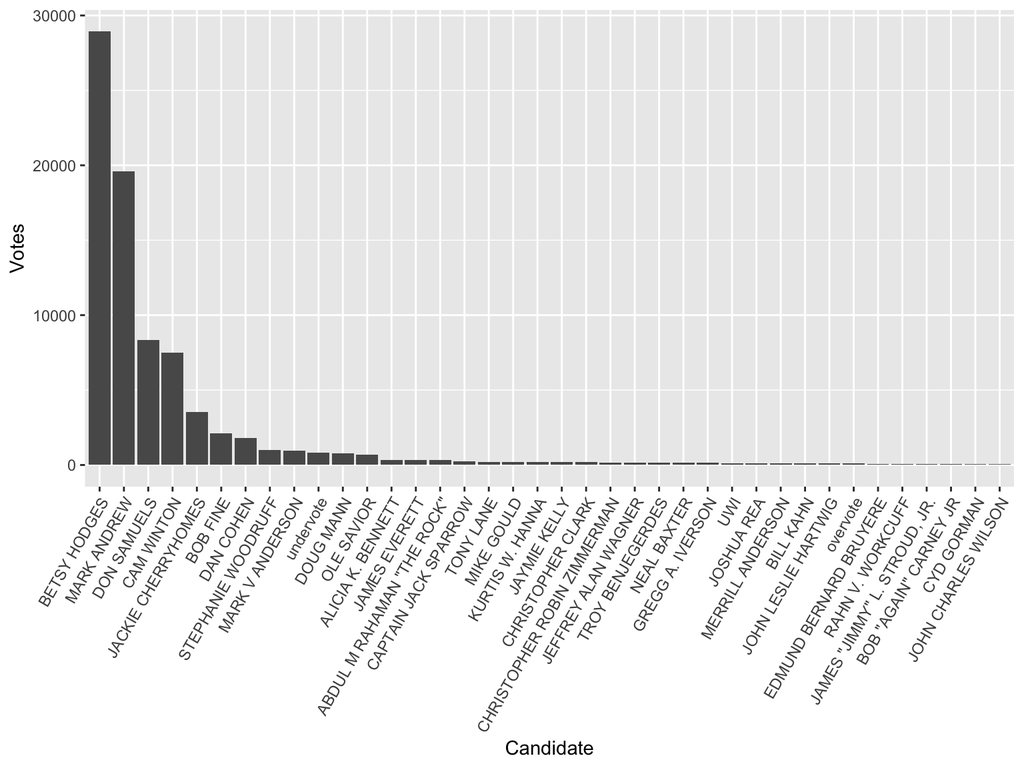

```r
# sorted bar chart
ggplot(data = VoteResults,
       aes(x = reorder(First, desc(votes)), y = votes )) +
       geom_bar(stat = 'identity') +
       theme(axis.text.x = element_text(angle = 60, hjust = 1)) +
       ylab("Votes") +
       xlab("Candidate")
```

This graph reflects the following data table (only part of which is shown):

```r
# we'll get to know these functions better soon
VoteResults %>%
  arrange( desc(votes) ) %>%
  head()
```

```
## # A tibble: 6 × 2
##   First              votes
##   <chr>              <int>
## 1 BETSY HODGES       28935
## 2 MARK ANDREW        19584
## 3 DON SAMUELS         8335
## 4 CAM WINTON          7511
## 5 JACKIE CHERRYHOMES  3524
## 6 BOB FINE            2094
```

Compare the `Minneapolis2013` data table and the wrangled data table printed above.

1. Do they have the same number of cases?
2. Do the cases in the two tables represent the same sort of thing?
3. Do the two tables have any variable(s) in common?
4. How are the two tables are related to one another?

# Why we wrangle

Data wrangling **prepares** the data for analysis.

- convert to tidy form for computing
- prepare glyph-ready data for visualization
- prepare data for modeling (e.g., exploratory, inferential, predictive)

# Different types of functions

- Useful to have consistent language for data wrangling, just as we’ve done for visualization
- Some common function types:
  - **Reduction functions**
  - **Transformation functions**
  - **Data verbs**

**For each type of function, what type of object is required as an input and what type of object is produced as a result?**

- Relevant objects here include
  - scalars
  - variables
  - data frames

# Different types of functions

- **Reduction functions**
  - inputs are **variables**
  - results are **scalar**
  - examples: `sum()`, `mean()`, `sd()`, `n()`, `n_distinct()`
- **Transformation functions**
  - inputs are **variables**;
  - results are **variable**
  - examples: `mutate`, `rename`
    - utilizes functions/operators such as +, -, *, /, ^, logicals, `round()`, `log()`
- **Data verbs**
  - inputs are **data frames**
  - results are **data frames**
  - examples: `summarise()`, `group_by()`

#### Any surprises above?

- `summarise()` as a data verb? Why not a reduction function??

# `summarise` and `group_by`

- `summarise()` — turns multiple cases into a single case using reduction functions. “Aggregate” is synonym for “summarise.”
- `group_by()` — modifies the action of reduction functions so that they give a single value for different groups of cases in a data frame.

### Summarise

To illustrate the uses of summarise(), look at the WorldCities data frame (in the dcData package) with information about the most populous cities in each country.

```r
data(WorldCities)
```

A simple summary of the data is a count of the number of cities.

```r
WorldCities %>%
  summarise(count = n())
```

```
##   count
## 1 23018
```

The reduction function is `n()`. The expression `count = n()` means that the output data frame should have a variable named count containing the results of n().

Perhaps you want to know the total population in these cities, or the average population per city or the smallest city in the table.

```r
WorldCities %>%
  summarise(averPop  = mean(population, na.rm=TRUE),
            totalPop = sum(population, na.rm=TRUE),
            smallest = min(population, na.rm=TRUE))
```

```
##    averPop   totalPop smallest
## 1 112624.8 2592396767        0
```

The average city on the list has about 110,000 people. The total population of people living in these cities is about 2.6 billion — a bit more than one-third of the world population. The smallest city has … zero people! Evidently, the `WorldCities` data frame has one or more cases that are not really cities.

Some things to notice about the use of `summarise()`:

- The chaining syntax, %>% has been used to pass the first argument to `summarize()`. This will be useful later on, when there is more than one step in a transfiguration. It’s OK to end a line with `%>%`, but never start a line with it.
- The output of `summarise()` is a data frame. (In this example the output has only one case, but it is still a data frame.) *`summarise()` takes named arguments. The name of an argument is taken as the name of the corresponding variable created by `summarise()`.

### group_by example

Number of cities in `WorldCities` broken down by country.

```r
WorldCities %>%
  group_by(country) %>%
  summarise(count = n())
```

```
## # A tibble: 243 × 2
##    country count
##    <chr>   <int>
##  1 AD          2
##  2 AE         12
##  3 AF         50
##  4 AG          1
##  5 AI          1
##  6 AL         20
##  7 AM         17
##  8 AO         27
##  9 AR        201
## 10 AS          1
## # ℹ 233 more rows
```

# Another Example

NCHS contains records of body shape, health, and mortality of 31126 people.

One of the variables in NCHS is hdl — HDL cholesterol. (HDL is the “good” kind of cholesterol, as opposed to LDL cholesterol, which is reported in the chol variable).

Suppose you want to know a typical HDL level for the people enrolled in NCHS. A typical value will be a fair representative of all the cases. It combines together information found in the individual cases. Since all the cases are being combined, `summarise()` is appropriate.

```r
data(NCHS, package = "dcData")
NCHS %>%
  summarise(typical = mean(hdl, na.rm = TRUE))
```

```
##    typical
## 1 52.37404
```

```r
NCHS %>%
  summarise(typical = mean(hdl, na.rm = TRUE),
            tallest = max(height, na.rm = TRUE))
```

```
##    typical tallest
## 1 52.37404   2.044
```

`na.rm = TRUE` instructs the reduction function to ignore missing data. The table below shows what happens without `na.rm = TRUE`, the missing data shapes the result and no useful information is produced.

```r
NCHS %>%
  summarise(typical = mean(hdl),
            tallest = max(height))
```

```
##   typical tallest
## 1      NA      NA
```

A division into groups by sex:

```r
NCHS %>%
  group_by(sex) %>%
  summarise(typical = mean(hdl, na.rm = TRUE),
            tallest = max(height, na.rm = TRUE))
```

```
## # A tibble: 2 × 3
##   sex    typical tallest
##   <fct>    <dbl>   <dbl>
## 1 female    55.7    1.87
## 2 male      48.9    2.04
```

The division is into smokers and non-smokers of each sex.

```r
NCHS %>%
  group_by( sex, smoker ) %>%
  summarise(typical = mean(hdl, na.rm=TRUE),
            tallest = min(height, na.rm=TRUE))
```

[output not shown]

```
## # A tibble: 6 × 4
## # Groups:   sex [2]
##   sex    smoker typical tallest
##   <fct>  <fct>    <dbl>   <dbl>
## 1 female no        56.1   0.797
## 2 female yes       53.5   1.40
## 3 female <NA>      53.1   0.928
## 4 male   no        49.2   0.79
## 5 male   yes       47.8   1.52
## 6 male   <NA>      45.8   1.05
```

# Baby Name Example

The BabyNames data frame contains this information implicitly. Before the information can be graphed, you need to wrangle the existing data frame into glyph-ready form.

Say we want to create a graph to plot total number of male and female briths each year. We need to wrangle our data into Glyph Ready Form.

```r
data("BabyNames")
YearlyBirths <-
  BabyNames %>%
  group_by(year, sex) %>%
  summarise(births = sum(count))
head(YearlyBirths)
```

```
## # A tibble: 6 × 3
## # Groups:   year [3]
##    year sex   births
##   <int> <chr>  <int>
## 1  1880 F      90993
## 2  1880 M     110491
## 3  1881 F      91954
## 4  1881 M     100746
## 5  1882 F     107850
## 6  1882 M     113687
```

This is in Glyph ready form!

We can now create our plot

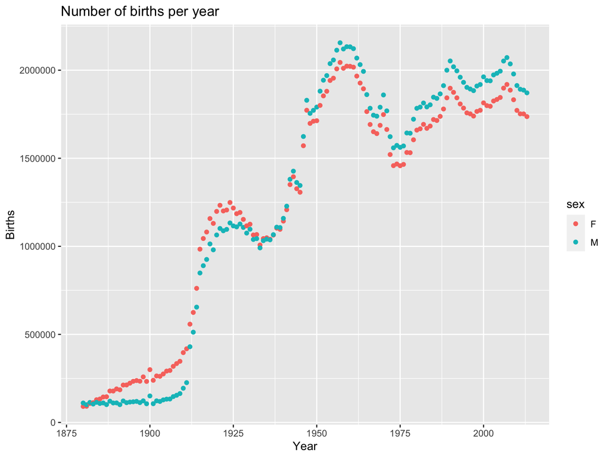

```r
ggplot(YearlyBirths, aes(x = year , y = births, color = sex)) +
  geom_point() +
  ylab("Births") +
  xlab("Year") +
  ggtitle("Number of births per year")
```

# Let’s use some other reduction functions, transformation functions, and data verbs with the some NFL data

```r
dat.football <- read_tsv(file = "https://raw.githubusercontent.com/ada-lovecraft/ProcessingSketches/master/Bits%20and%20Pieces/Football_Stuff/data/nfl-salaries.tsv")
head(dat.football) #default is first 6 rows and all the columns
```

```
## # A tibble: 6 × 6
##   PlayerName              Position  Salary NextSalary SalaryCap Team
##   <chr>                   <chr>      <dbl>      <dbl>     <dbl> <chr>
## 1 Tony Romo               QB       9000000   11500000  18905000 Dallas Cowboys
## 2 Anthony Spencer         LB       8800000          0   8800000 Dallas Cowboys
## 3 Jay Ratliff             DE       4875000          0   6475000 Dallas Cowboys
## 4 Terence Newman (buyout) CB       4800000          0   4800000 Dallas Cowboys
## 5 Orlando Scandrick       CB       4700000          0   7700000 Dallas Cowboys
## 6 DeMarcus Ware           LB       4500000    5500000  10303000 Dallas Cowboys
```

```r
head(dat.football, n =10)
```

```
## # A tibble: 10 × 6
##    PlayerName              Position  Salary NextSalary SalaryCap Team
##    <chr>                   <chr>      <dbl>      <dbl>     <dbl> <chr>
##  1 Tony Romo               QB       9000000   11500000  18905000 Dallas Cowboys
##  2 Anthony Spencer         LB       8800000          0   8800000 Dallas Cowboys
##  3 Jay Ratliff             DE       4875000          0   6475000 Dallas Cowboys
##  4 Terence Newman (buyout) CB       4800000          0   4800000 Dallas Cowboys
##  5 Orlando Scandrick       CB       4700000          0   7700000 Dallas Cowboys
##  6 DeMarcus Ware           LB       4500000    5500000  10303000 Dallas Cowboys
##  7 Jason Witten            TE       3641000          0   5841000 Dallas Cowboys
##  8 Marcus Spears           DE       2000000    2000000   2700000 Dallas Cowboys
##  9 Kenyon Coleman          DE       1900000          0   2245000 Dallas Cowboys
## 10 Jason Hatcher           DE       1500000    2000000   2100000 Dallas Cowboys
```

```r
dat.football %>%
  slice(1:10)
```

```
## # A tibble: 10 × 6
##    PlayerName              Position  Salary NextSalary SalaryCap Team
##    <chr>                   <chr>      <dbl>      <dbl>     <dbl> <chr>
##  1 Tony Romo               QB       9000000   11500000  18905000 Dallas Cowboys
##  2 Anthony Spencer         LB       8800000          0   8800000 Dallas Cowboys
##  3 Jay Ratliff             DE       4875000          0   6475000 Dallas Cowboys
##  4 Terence Newman (buyout) CB       4800000          0   4800000 Dallas Cowboys
##  5 Orlando Scandrick       CB       4700000          0   7700000 Dallas Cowboys
##  6 DeMarcus Ware           LB       4500000    5500000  10303000 Dallas Cowboys
##  7 Jason Witten            TE       3641000          0   5841000 Dallas Cowboys
##  8 Marcus Spears           DE       2000000    2000000   2700000 Dallas Cowboys
##  9 Kenyon Coleman          DE       1900000          0   2245000 Dallas Cowboys
## 10 Jason Hatcher           DE       1500000    2000000   2100000 Dallas Cowboys
```

```r
## Get the dimensions of the data
dim(dat.football)
```

```
## [1] 1501    6
```

```r
## Get the column names of the data
colnames(dat.football)
```

```
## [1] "PlayerName" "Position"   "Salary"     "NextSalary" "SalaryCap"
## [6] "Team"
```

```r
## Get the row names of the data
rownames(dat.football) #meaningless! (most times they will be)
```

[output not shown]

[output cut: 136 more lines]

```r
## Get a summary of the data
## sumamry is not summarize!
summary(dat.football) # gives summary info by column
```

```
##   PlayerName          Position             Salary           NextSalary
##  Length:1501        Length:1501        Min.   :    2333   Min.   :       0
##  Class :character   Class :character   1st Qu.:  490000   1st Qu.:       0
##  Mode  :character   Mode  :character   Median :  615000   Median :  555000
##                                        Mean   : 1566829   Mean   : 1248008
##                                        3rd Qu.: 1700000   3rd Qu.:  900000
##                                        Max.   :18000000   Max.   :20000000
##    SalaryCap            Team
##  Min.   :       0   Length:1501
##  1st Qu.:  515946   Class :character
##  Median :  770000   Mode  :character
##  Mean   : 2171577
##  3rd Qu.: 2700000
##  Max.   :20250000
```

Now lets look at some `tidyverse` functions.

```r
#Filter
dat.football %>%
  filter(Team == "Denver Broncos")
```

```
## # A tibble: 58 × 6
##    PlayerName     Position   Salary NextSalary SalaryCap Team
##    <chr>          <chr>       <dbl>      <dbl>     <dbl> <chr>
##  1 Peyton Manning QB       18000000   20000000  18000000 Denver Broncos
##  2 Elvis Dumervil DE       14000000   12000000  14500000 Denver Broncos
##  3 Champ Bailey   CB        8000000    9000000   9500000 Denver Broncos
##  4 Brian Dawkins  S         6000000    6000000   9156000 Denver Broncos
##  5 D.J. Williams  LB        5000000    6000000   5000000 Denver Broncos
##  6 Andre' Goodman CB        4620000    3960000   5580000 Denver Broncos
##  7 Ty Warren      DT        4000000          0   5250000 Denver Broncos
##  8 Chris Kuper    G         3500000    4500000   3500000 Denver Broncos
##  9 Ryan Clady     T         3500000          0   4010000 Denver Broncos
## 10 Matt Prater    K         2665000          0   2665000 Denver Broncos
## # ℹ 48 more rows
```

```r
#Arrange
dat.football %>%
  arrange(Salary) #lowest to highest
```

```
## # A tibble: 1,501 × 6
##    PlayerName               Position Salary NextSalary SalaryCap Team
##    <chr>                    <chr>     <dbl>      <dbl>     <dbl> <chr>
##  1 Richard Dickson (buyout) TE         2333          0      2333 Detroit Lions
##  2 Kevin Haslam (buyout)    T          3333          0      3333 Jacksonville J…
##  3 Curtis Painter (buyout)  QB        22750          0     22750 Indianapolis C…
##  4 Jon Corto (Buyout)       S         25000          0     25000 Buffalo Bills
##  5 George Selvie (buyout)   DE        27976          0     27976 St. Louis Rams
##  6 David Buehler (buyout)   K         37125          0     37125 Dallas Cowboys
##  7 Markell Carter           DE        70539          0    390000 New England Pa…
##  8 Morgan Trent (Buyout)    CB        84000          0     84000 Cincinnati Ben…
##  9 Anthony Herrera (buyout) G        100000          0    100000 Minnesota Viki…
## 10 Jordan Todman (buyout)   RB       128094          0    128094 San Diego Char…
## # ℹ 1,491 more rows
```

```r
dat.football %>%
  arrange(desc(Salary)) #highest to lowest
```

```
## # A tibble: 1,501 × 6
##    PlayerName       Position   Salary NextSalary SalaryCap Team
##    <chr>            <chr>       <dbl>      <dbl>     <dbl> <chr>
##  1 Peyton Manning   QB       18000000   20000000  18000000 Denver Broncos
##  2 Drew Brees       QB       15760000          0  15760000 New Orleans Saints
##  3 Dwight Freeney   DE       14035000          0  19035000 Indianapolis Colts
##  4 Elvis Dumervil   DE       14000000   12000000  14500000 Denver Broncos
##  5 Michael Vick     QB       12500000   12500000  13900000 Philadelphia Eagles
##  6 Sam Bradford     QB       12000000    9000000  15594800 St. Louis Rams
##  7 Jared Allen      DE       11619850   14280612  14203183 Minnesota Vikings
##  8 Matthew Stafford QB       11500000    1200000  17258750 Detroit Lions
##  9 Matt Ryan        QB       11500000   10000000  13000000 Atlanta Falcons
## 10 Tamba Hali       DE       11250000   12250000  14250000 Kansas City Chiefs
## # ℹ 1,491 more rows
```

```r
#Select
dat.football %>%
  select(PlayerName, Position)
```

```
## # A tibble: 1,501 × 2
##    PlayerName              Position
##    <chr>                   <chr>
##  1 Tony Romo               QB
##  2 Anthony Spencer         LB
##  3 Jay Ratliff             DE
##  4 Terence Newman (buyout) CB
##  5 Orlando Scandrick       CB
##  6 DeMarcus Ware           LB
##  7 Jason Witten            TE
##  8 Marcus Spears           DE
##  9 Kenyon Coleman          DE
## 10 Jason Hatcher           DE
## # ℹ 1,491 more rows
```

```r
#Rename
dat.football %>%
  rename(TeamName = Team)
```

```
## # A tibble: 1,501 × 6
##    PlayerName              Position  Salary NextSalary SalaryCap TeamName
##    <chr>                   <chr>      <dbl>      <dbl>     <dbl> <chr>
##  1 Tony Romo               QB       9000000   11500000  18905000 Dallas Cowboys
##  2 Anthony Spencer         LB       8800000          0   8800000 Dallas Cowboys
##  3 Jay Ratliff             DE       4875000          0   6475000 Dallas Cowboys
##  4 Terence Newman (buyout) CB       4800000          0   4800000 Dallas Cowboys
##  5 Orlando Scandrick       CB       4700000          0   7700000 Dallas Cowboys
##  6 DeMarcus Ware           LB       4500000    5500000  10303000 Dallas Cowboys
##  7 Jason Witten            TE       3641000          0   5841000 Dallas Cowboys
##  8 Marcus Spears           DE       2000000    2000000   2700000 Dallas Cowboys
##  9 Kenyon Coleman          DE       1900000          0   2245000 Dallas Cowboys
## 10 Jason Hatcher           DE       1500000    2000000   2100000 Dallas Cowboys
## # ℹ 1,491 more rows
```

```r
#Mutate
dat.football %>%
  mutate(PercentOfCap = Salary / SalaryCap * 100)
```

```
## # A tibble: 1,501 × 7
##    PlayerName            Position Salary NextSalary SalaryCap Team  PercentOfCap
##    <chr>                 <chr>     <dbl>      <dbl>     <dbl> <chr>        <dbl>
##  1 Tony Romo             QB       9   e6   11500000  18905000 Dall…         47.6
##  2 Anthony Spencer       LB       8.80e6          0   8800000 Dall…        100
##  3 Jay Ratliff           DE       4.88e6          0   6475000 Dall…         75.3
##  4 Terence Newman (buyo… CB       4.80e6          0   4800000 Dall…        100
##  5 Orlando Scandrick     CB       4.70e6          0   7700000 Dall…         61.0
##  6 DeMarcus Ware         LB       4.50e6    5500000  10303000 Dall…         43.7
##  7 Jason Witten          TE       3.64e6          0   5841000 Dall…         62.3
##  8 Marcus Spears         DE       2   e6    2000000   2700000 Dall…         74.1
##  9 Kenyon Coleman        DE       1.9 e6          0   2245000 Dall…         84.6
## 10 Jason Hatcher         DE       1.5 e6    2000000   2100000 Dall…         71.4
## # ℹ 1,491 more rows
```

```r
#Group
dat.football %>%
  group_by(Team) #doesn't look like it did anything???
```

```
## # A tibble: 1,501 × 6
## # Groups:   Team [31]
##    PlayerName              Position  Salary NextSalary SalaryCap Team
##    <chr>                   <chr>      <dbl>      <dbl>     <dbl> <chr>
##  1 Tony Romo               QB       9000000   11500000  18905000 Dallas Cowboys
##  2 Anthony Spencer         LB       8800000          0   8800000 Dallas Cowboys
##  3 Jay Ratliff             DE       4875000          0   6475000 Dallas Cowboys
##  4 Terence Newman (buyout) CB       4800000          0   4800000 Dallas Cowboys
##  5 Orlando Scandrick       CB       4700000          0   7700000 Dallas Cowboys
##  6 DeMarcus Ware           LB       4500000    5500000  10303000 Dallas Cowboys
##  7 Jason Witten            TE       3641000          0   5841000 Dallas Cowboys
##  8 Marcus Spears           DE       2000000    2000000   2700000 Dallas Cowboys
##  9 Kenyon Coleman          DE       1900000          0   2245000 Dallas Cowboys
## 10 Jason Hatcher           DE       1500000    2000000   2100000 Dallas Cowboys
## # ℹ 1,491 more rows
```

```r
#Summarise
?summarise

dat.football %>%
  summarise(MeanSalary = mean(Salary))
```

```
## # A tibble: 1 × 1
##   MeanSalary
##        <dbl>
## 1   1566829.
```

```r
dat.football %>%
  summarize(SdSalary = sd(Salary))
```

```
## # A tibble: 1 × 1
##   SdSalary
##      <dbl>
## 1 2099740.
```

```r
dat.football %>%
  group_by(Team) %>%
  summarise(MeanSalary = mean(Salary), .groups = "keep" )
```

```
## # A tibble: 31 × 2
## # Groups:   Team [31]
##    Team               MeanSalary
##    <chr>                   <dbl>
##  1 Arizona Cardinals    1594186.
##  2 Atlanta Falcons      1828407.
##  3 Baltimore Ravens     2156606.
##  4 Buffalo Bills        1315185.
##  5 Carolina Panthers    1353846.
##  6 Chicago Bears        1758006.
##  7 Cincinnati Bengals   1283529.
##  8 Cleveland Browns     1573352.
##  9 Dallas Cowboys       1480814.
## 10 Denver Broncos       1683837.
## # ℹ 21 more rows
```

# Exploratory Analysis - Combining it all together

What is the highest salary?

```r
max(dat.football$Salary)
```

```
## [1] 1.8e+07
```

Which player has this salary?

```r
# Method 1 (no tidyverse functions)
max.salary <- max(dat.football$Salary) #get the max salary
row.max.salary <- dat.football$Salary == max.salary
answer.1 <- dat.football$PlayerName[row.max.salary]

#c(1, 2, 3, 4)[c(FALSE, FALSE, TRUE, FALSE)]

# Method 2 (tidyverse functions)
answer.2 <- dat.football %>%
  filter(Salary == max(Salary) ) %>%
  select(PlayerName)

# Method 3 (tidyverse functions)
answer.3 <- dat.football %>%
  arrange(desc(Salary)) %>%
  slice(1) %>%
  select(PlayerName)

## Whats the benefit of using tidyverse functions?
library(utils)
object.size(c(max.salary, row.max.salary, answer.1))
```

```
## 12304 bytes
```

```r
object.size(answer.2)
```

```
## 944 bytes
```

```r
object.size(answer.3)
```

```
## 944 bytes
```

```r
944/12304 # used only 7% of the storage space by using tidyverse!
```

```
## [1] 0.07672302
```

What is the team with the highest paid roster, and what was their total pay? What is the team with the lowest paid roster, and what was their total pay?

```r
Paid <- dat.football %>%
  group_by(Team)%>%
  summarize(PaidRoster = sum(Salary)) %>%
  arrange(desc(PaidRoster))

Paid[1, ] #highest paid
```

```
## # A tibble: 1 × 2
##   Team                 PaidRoster
##   <chr>                     <dbl>
## 1 Tampa Bay Buccaneers  106247707
```

```r
# how many teams are in our data set>

dim(Paid)
```

```
## [1] 31  2
```

```r
length(unique(dat.football$Team))
```

```
## [1] 31
```

```r
Paid[31, ]
```

```
## # A tibble: 1 × 2
##   Team               PaidRoster
##   <chr>                   <dbl>
## 1 Cincinnati Bengals   51341172
```

```r
#Bonus Question, if I said this data was from 2016 what team is missing from our data?
sort(unique(dat.football$Team))
```

```
##  [1] "Arizona Cardinals"    "Atlanta Falcons"      "Baltimore Ravens"
##  [4] "Buffalo Bills"        "Carolina Panthers"    "Chicago Bears"
##  [7] "Cincinnati Bengals"   "Cleveland Browns"     "Dallas Cowboys"
## [10] "Denver Broncos"       "Detroit Lions"        "Green Bay Packers"
## [13] "Houston Texans"       "Indianapolis Colts"   "Jacksonville Jaguars"
## [16] "Kansas City Chiefs"   "Miami Dolphins"       "Minnesota Vikings"
## [19] "New England Patriots" "New Orleans Saints"   "New York Giants"
## [22] "New York Jets"        "Oakland Raiders"      "Philadelphia Eagles"
## [25] "Pittsburgh Steelers"  "San Diego Chargers"   "San Francisco 49ers"
## [28] "Seattle Seahawks"     "St. Louis Rams"       "Tampa Bay Buccaneers"
## [31] "Washington Redskins"
```

# Pivot wider and Pivot Longer

`pivot_wider()` and `pivot_longer()` are two VERY useful functions in the `tidyverse`. We do not need them this week, but I wanted to introduce them if you want to get ahead.

```r
## Pivot Wider
?pivot_wider

# names_from = new column names
# value_from = values to fill in in the table
us_rent_income
```

```
## # A tibble: 104 × 5
##    GEOID NAME       variable estimate   moe
##    <chr> <chr>      <chr>       <dbl> <dbl>
##  1 01    Alabama    income      24476   136
##  2 01    Alabama    rent          747     3
##  3 02    Alaska     income      32940   508
##  4 02    Alaska     rent         1200    13
##  5 04    Arizona    income      27517   148
##  6 04    Arizona    rent          972     4
##  7 05    Arkansas   income      23789   165
##  8 05    Arkansas   rent          709     5
##  9 06    California income      29454   109
## 10 06    California rent         1358     3
## # ℹ 94 more rows
```

```r
us_rent_income %>%
  pivot_wider(
    names_from = variable,
    values_from = c(estimate, moe)
  )
```

```
## # A tibble: 52 × 6
##    GEOID NAME                 estimate_income estimate_rent moe_income moe_rent
##    <chr> <chr>                          <dbl>         <dbl>      <dbl>    <dbl>
##  1 01    Alabama                        24476           747        136        3
##  2 02    Alaska                         32940          1200        508       13
##  3 04    Arizona                        27517           972        148        4
##  4 05    Arkansas                       23789           709        165        5
##  5 06    California                     29454          1358        109        3
##  6 08    Colorado                       32401          1125        109        5
##  7 09    Connecticut                    35326          1123        195        5
##  8 10    Delaware                       31560          1076        247       10
##  9 11    District of Columbia           43198          1424        681       17
## 10 12    Florida                        25952          1077         70        3
## # ℹ 42 more rows
```

```r
# is the above table tidy? What is each case?

## Pivot Longer
?pivot_longer
#name_to = new column name that will contain the old column names
#values_to = new column name that will contain the data from the original table
relig_income
```

```
## # A tibble: 18 × 11
##    religion `<$10k` `$10-20k` `$20-30k` `$30-40k` `$40-50k` `$50-75k` `$75-100k`
##    <chr>      <dbl>     <dbl>     <dbl>     <dbl>     <dbl>     <dbl>      <dbl>
##  1 Agnostic      27        34        60        81        76       137        122
##  2 Atheist       12        27        37        52        35        70         73
##  3 Buddhist      27        21        30        34        33        58         62
##  4 Catholic     418       617       732       670       638      1116        949
##  5 Don’t k…      15        14        15        11        10        35         21
##  6 Evangel…     575       869      1064       982       881      1486        949
##  7 Hindu          1         9         7         9        11        34         47
##  8 Histori…     228       244       236       238       197       223        131
##  9 Jehovah…      20        27        24        24        21        30         15
## 10 Jewish        19        19        25        25        30        95         69
## 11 Mainlin…     289       495       619       655       651      1107        939
## 12 Mormon        29        40        48        51        56       112         85
## 13 Muslim         6         7         9        10         9        23         16
## 14 Orthodox      13        17        23        32        32        47         38
## 15 Other C…       9         7        11        13        13        14         18
## 16 Other F…      20        33        40        46        49        63         46
## 17 Other W…       5         2         3         4         2         7          3
## 18 Unaffil…     217       299       374       365       341       528        407
## # ℹ 3 more variables: `$100-150k` <dbl>, `>150k` <dbl>,
## #   `Don't know/refused` <dbl>
```

```r
relig_income %>%
  pivot_longer(!religion,  # every column but religion
               names_to = "income",
               values_to = "count")
```

```
## # A tibble: 180 × 3
##    religion income             count
##    <chr>    <chr>              <dbl>
##  1 Agnostic <$10k                 27
##  2 Agnostic $10-20k               34
##  3 Agnostic $20-30k               60
##  4 Agnostic $30-40k               81
##  5 Agnostic $40-50k               76
##  6 Agnostic $50-75k              137
##  7 Agnostic $75-100k             122
##  8 Agnostic $100-150k            109
##  9 Agnostic >150k                 84
## 10 Agnostic Don't know/refused    96
## # ℹ 170 more rows
```

```r
# Is the above table Tidy? What is a case?

world_bank_pop
```

```
## # A tibble: 1,064 × 20
##    country indicator      `2000`  `2001`  `2002`  `2003`  `2004`  `2005`  `2006`
##    <chr>   <chr>           <dbl>   <dbl>   <dbl>   <dbl>   <dbl>   <dbl>   <dbl>
##  1 ABW     SP.URB.TOTL    4.16e4 4.20e+4 4.22e+4 4.23e+4 4.23e+4 4.24e+4 4.26e+4
##  2 ABW     SP.URB.GROW    1.66e0 9.56e-1 4.01e-1 1.97e-1 9.46e-2 1.94e-1 3.67e-1
##  3 ABW     SP.POP.TOTL    8.91e4 9.07e+4 9.18e+4 9.27e+4 9.35e+4 9.45e+4 9.56e+4
##  4 ABW     SP.POP.GROW    2.54e0 1.77e+0 1.19e+0 9.97e-1 9.01e-1 1.00e+0 1.18e+0
##  5 AFE     SP.URB.TOTL    1.16e8 1.20e+8 1.24e+8 1.29e+8 1.34e+8 1.39e+8 1.44e+8
##  6 AFE     SP.URB.GROW    3.60e0 3.66e+0 3.72e+0 3.71e+0 3.74e+0 3.81e+0 3.81e+0
##  7 AFE     SP.POP.TOTL    4.02e8 4.12e+8 4.23e+8 4.34e+8 4.45e+8 4.57e+8 4.70e+8
##  8 AFE     SP.POP.GROW    2.58e0 2.59e+0 2.61e+0 2.62e+0 2.64e+0 2.67e+0 2.70e+0
##  9 AFG     SP.URB.TOTL    4.31e6 4.36e+6 4.67e+6 5.06e+6 5.30e+6 5.54e+6 5.83e+6
## 10 AFG     SP.URB.GROW    1.86e0 1.15e+0 6.86e+0 7.95e+0 4.59e+0 4.47e+0 5.03e+0
## # ℹ 1,054 more rows
## # ℹ 11 more variables: `2007` <dbl>, `2008` <dbl>, `2009` <dbl>, `2010` <dbl>,
## #   `2011` <dbl>, `2012` <dbl>, `2013` <dbl>, `2014` <dbl>, `2015` <dbl>,
## #   `2016` <dbl>, `2017` <dbl>
```

```r
world_bank_pop %>%
  pivot_longer(!c(country, indicator),
               names_to = "year",
               values_to = "count")
```

```
## # A tibble: 19,152 × 4
##    country indicator   year  count
##    <chr>   <chr>       <chr> <dbl>
##  1 ABW     SP.URB.TOTL 2000  41625
##  2 ABW     SP.URB.TOTL 2001  42025
##  3 ABW     SP.URB.TOTL 2002  42194
##  4 ABW     SP.URB.TOTL 2003  42277
##  5 ABW     SP.URB.TOTL 2004  42317
##  6 ABW     SP.URB.TOTL 2005  42399
##  7 ABW     SP.URB.TOTL 2006  42555
##  8 ABW     SP.URB.TOTL 2007  42729
##  9 ABW     SP.URB.TOTL 2008  42906
## 10 ABW     SP.URB.TOTL 2009  43079
## # ℹ 19,142 more rows
```

```r
# is the above table tidy? What is a case?
```